# Test of the Hybrid Scheme implementation

## Test

We will check if our implementation of the Hybrid scheme is correct, thanks to McCrickerd who made an available python code where he implemented the rough Bergomi model using the Hybrid Scheme.

https://github.com/ryanmccrickerd/rough_bergomi

Using our class, we will generate a Brownian which will be used to create the fBm and the asset price. Then we will use this same Brownian in McCrickerd library to check that the paths are the same.

We can see that both paths are indistiguishable.

Now we will do the reverse, ie, we will generate a Brownian with McCrickerd library and incorporate it in our class.

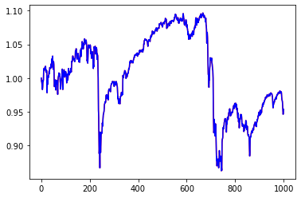

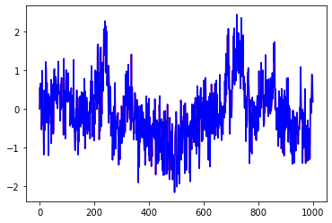

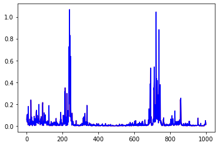

```python
V_0 = 0.235**2
nu = 1.9
S0 = 1
rho = -1

# Our class
test = rBergomi_h( paths = 10, N = 1000, T = 1.00, H = 0.1)
W = test.dW() #our Brownian
W_h = test.W_h(W)
V = test.V(V_0, nu, W_h)

S = test.S(S0, rho, W, V)


# McCrikerd library

rB = rBergomi_MC(n = 1000, N = 10, T = 1.0, a = -0.4)
dW2 = rB.dW2()
Y = rB.Y(W) # here we incorporate our Brownian W
dB = rB.dB(W, dW2, rho = -1) # here again
V_M = rB.V(Y, xi = 0.235**2, eta = 1.9)
S_M = rB.S(V_M, dB,1)



# We plot both resulting asset trajectory
# in blue our class
plt.plot(S_M[0,:], color = 'red')
plt.plot(S[0,:], color='blue')
plt.show()

plt.plot(Y[0,:], color = 'red')
plt.plot(W_h[0,:], color='blue')
plt.show()

plt.plot(V_M[0,:], color = 'red')
plt.plot(V[0,:], color = 'blue')
plt.show()
```

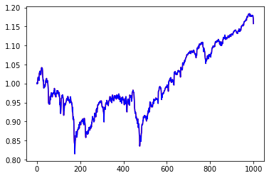

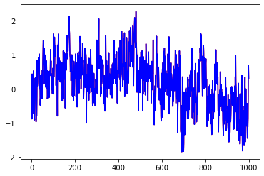

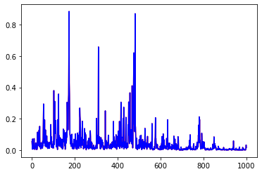

```python
V_0 = 0.235**2
nu = 1.9
S0 = 1
rho = -1

# McCrikerd library

rB = rBergomi_MC(n = 1000, N = 10, T = 1.0, a = -0.4)
dW1 = rB.dW1() #Mccrickerd 's Brownian
dW2 = rB.dW2()
Y = rB.Y(dW1)
dB = rB.dB(dW1, dW2, rho = -1)
V_M = rB.V(Y, xi = 0.235**2, eta = 1.9)
S_M = rB.S(V_M, dB,1)
S1_M = rB.S1(V_M, dW1, rho, S0 = 1)



# Our class
test = rBergomi_h( paths = 10, N = 1000, T = 1.00, H = 0.1)
W_h = test.W_h(dW1) # here we incorporate McCrickerd's Brownian dW1
V = test.V(V_0, nu, W_h)
S = test.S(S0, rho, dW1, V) #here again


# We plot both resulting asset trajectory
# in blue our class
plt.plot(S_M[0,:], color = 'red')
plt.plot(S[0,:], color='blue')
plt.show()

plt.plot(Y[0,:], color = 'red')
plt.plot(W_h[0,:], color='blue')
plt.show()

plt.plot(V_M[0,:], color = 'red')
plt.plot(V[0,:], color = 'blue')
plt.show()
```

We find similar results.

### Computation time

We will generate from 1, 100,..., 10000 paths and record the time for both our class and McCrickerd's library.

```python
V_0 = 0.235**2
nu = 1.9
S0 = 1
rho = -1

path_ = np.arange(1,10000+100,100)
MC_comp = np.zeros(len(path_))
Class_comp = np.zeros(len(path_))
```

```python
#Mc Crickerd
for i in range(len(path_)):
    t1 = time()

    rB = rBergomi_MC(n = 100, N = path_[i], T = 1.0, a = -0.4) #From McCrickerd Library
    dW1 = rB.dW1()
    dW2 = rB.dW2()
    Y = rB.Y(dW1)
    dB = rB.dB(dW1, dW2, rho = -1)
    V_M = rB.V(Y, xi = 0.235**2, eta = 1.9)
    S_M = rB.S(V_M, dB,1)
    S1_M = rB.S1(V_M, dW1, rho, S0 = 1)

    t2 = time()

    MC_comp[i] = t2 - t1
```

```python
# Our Class
for i in range(len(path_)):
    t1 = time()

    test = rBergomi_h( paths = path_[i], N = 100, T = 1.00, H = 0.1)
    W = test.dW()
    W_h = test.W_h(W)
    V = test.V(V_0, nu, W_h)

    S = test.S(S0, rho, W, V)
    S1 = test.S1(S0, rho, W, V)

    t2 = time()
    Class_comp[i] = t2 - t1
```

Here we plot both recorded times w.r.t the number of paths

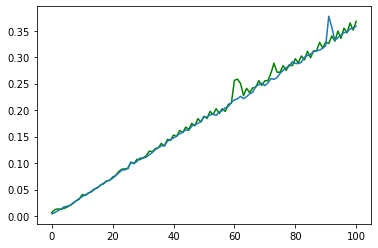

```python
# Our class in green
plt.plot(Class_comp, color = 'green')
plt.plot(MC_comp)
```